# Practica 2 - Datos Elegantes + Análisis de datos con Web Screpping

Mayteelsoon Guerra - Rita Rosas

2023-04-21

## Pregunta 1:

### 1.1 Descargar la página web de la URL indicada, y almacenarlo en un formato de R apto para ser tratado

```
## [1] 200
```

### 1.2 Analizar el contenido de la web, buscando el título de la página (que en HTML se etiqueta como “title”)

```
## [1] "MediaWiki"
```

### 1.3 Analizar el contenido de la web, buscando todos los enlaces (que en HTML se etiquetan como “a”), buscando el texto del enlace, así como la URL

```
## [1] "Jump to content" "Main page"       "Get MediaWiki"   "Get extensions"
## [5] "Tech blog"       "Contribute"
```

```
## [1] "#bodyContent"
## [2] "/wiki/MediaWiki"
## [3] "/wiki/Download"
## [4] "/wiki/Special:MyLanguage/Category:Extensions"
## [5] "//techblog.wikimedia.org/"
## [6] "/wiki/Special:MyLanguage/How_to_contribute"
```

### 1.4 Generar una tabla con cada enlace encontrado, indicando el texto que acompaña el enlace, y el número de veces que aparece un enlace con ese mismo objetivo.

```r
tabla <- data.frame(links_text = character(),
                    links_original_url = character(),
                    links_url = character(),
                    links_relative = character(),
                    links_internal = character(),
                    repeticiones = numeric(),
                    scraps = character(),
                    stringsAsFactors = FALSE)

frecuencia <- table(links_url)
```

### 1.5 Para cada enlace, seguirlo e indicar si está activo (podemos usar el código de status HTTP al hacer una petición a esa URL) aparece un enlace con ese mismo objetivo.

```
##        links_text                           links_original_url
## 1 Jump to content                                 #bodyContent
## 2       Main page                              /wiki/MediaWiki
## 3   Get MediaWiki                               /wiki/Download
## 4  Get extensions /wiki/Special:MyLanguage/Category:Extensions
## 5       Tech blog                    //techblog.wikimedia.org/
## 6      Contribute   /wiki/Special:MyLanguage/How_to_contribute
##                                                               links_url
## 1                  https://www.mediawiki.org/wiki/MediaWiki#bodyContent
## 2                              https://www.mediawiki.org/wiki/MediaWiki
## 3                               https://www.mediawiki.org/wiki/Download
## 4 https://www.mediawiki.org/wiki/Special:MyLanguage/Category:Extensions
## 5                                       https://techblog.wikimedia.org/
## 6   https://www.mediawiki.org/wiki/Special:MyLanguage/How_to_contribute
##   links_relative links_internal repeticiones scraps
## 1              S              S            1    200
## 2              S              S            5    200
## 3              S              S            1    200
## 4              S              S            1    200
## 5              S              S            1    200
## 6              S              S            2    200
```

## Pregunta 2:

### 2.1 Un histograma con la frecuencia de aparición de los enlaces, pero separado porURLs absolutas (con “http…”) y URLs relativas

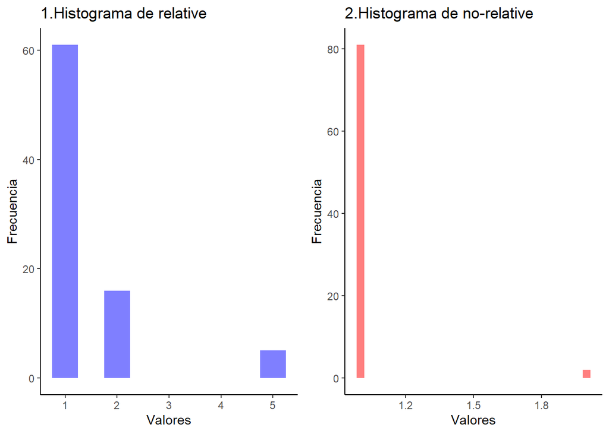

### 2.2 Un gráfico de barras indicando la suma de enlaces que apuntan a otros dominios o servicios vs. la suma de los otros enlaces.

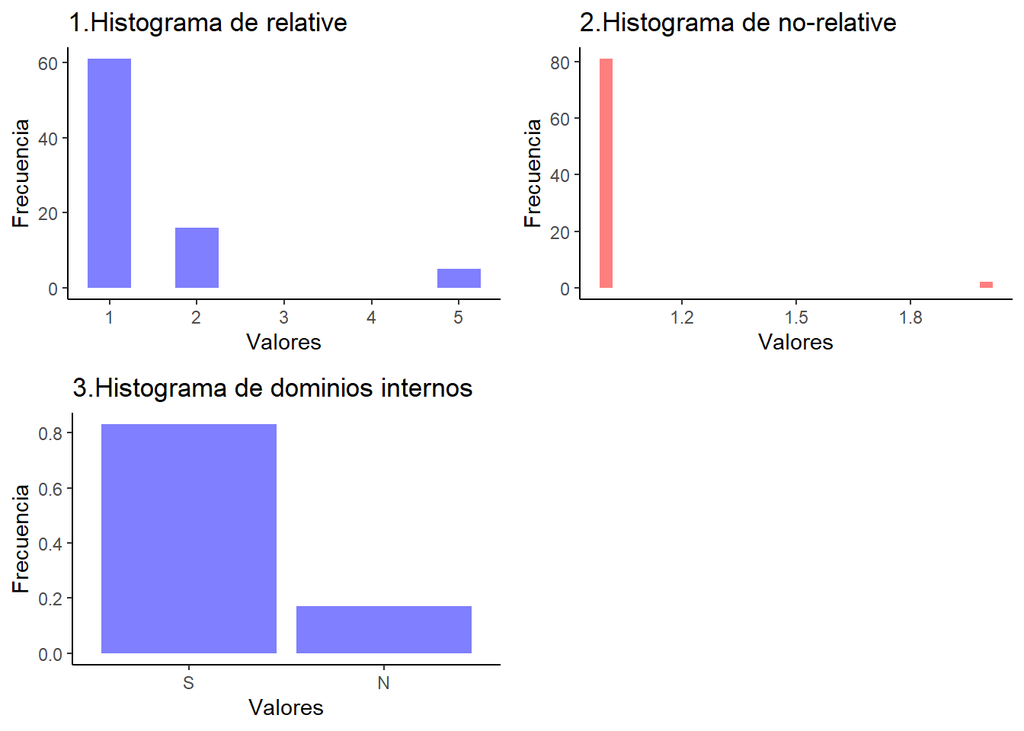

### 2.3 Un gráfico de tarta (pie chart) indicando los porcentajes de Status de nuestro análisis.

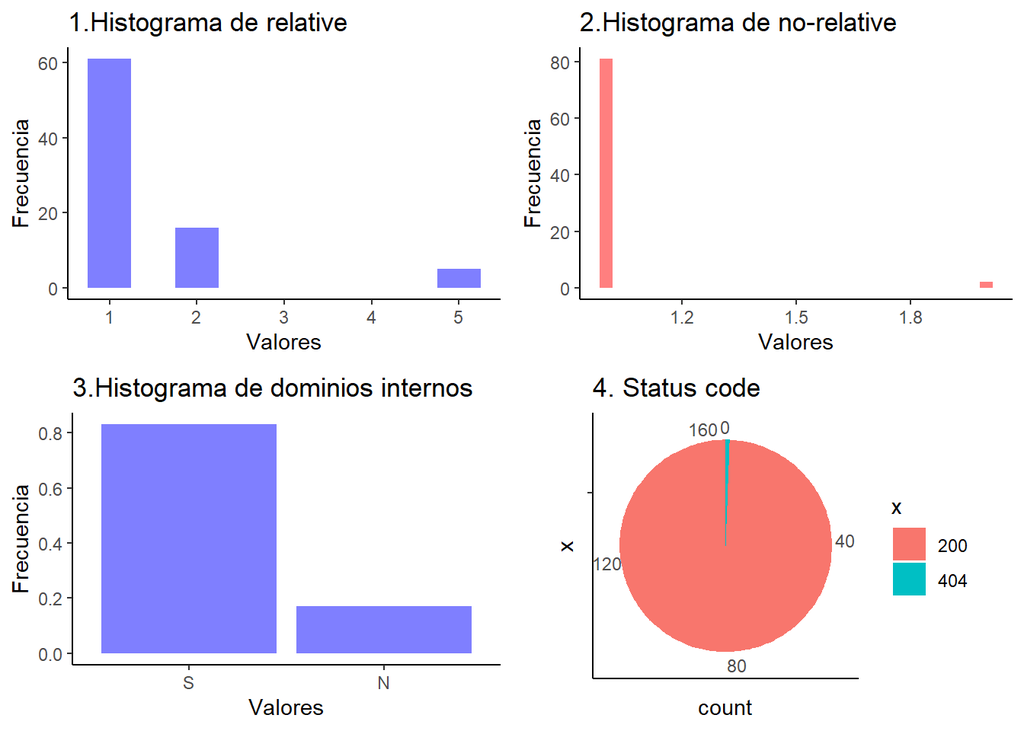